# Unit 6 - Potential Outcomes Framework

James Flynn

September 21, 2026

## Potential Outcomes Framework

- Causal Diagrams $\rightarrow$ Picture-y
- Potential Outcomes Framework $\rightarrow$ Number-y

Like with causal diagrams, the potential outcomes framework can help us get from simple regression to causal inference

## PO Framework (cont’d)

- PO framework is based on the idea of **counterfactual** outcomes
- These are based on what **would have** happened if a different policy was pursued
- Counterfactuals are not observed, so it is our job to estimate them
- Framework can help us figure out the best way to do this

## Example - Does summer school work?

- Meant to give struggling students extra help
- We want to know if students who attend summer school end up with a better GPA because of it
- Causal question: “If we send student to summer school (D), will their final GPA (Y) improve?”
- Can we regress final GPA on whether someone went to summer school?

## Let’s set it up

```r
pre_gpa <- runif(1000,max=4,min=0)
sumschl <- pre_gpa <1.5
ss_effect <- rnorm(1000,.5,.2)
noise <- rnorm(1000,0,.2)
fgpa_nss <- pre_gpa + noise
fgpa_ss <- pre_gpa + noise + ss_effect
fgpa_obs <- pre_gpa + noise + sumschl*ss_effect
sum_sch_df <- data.frame(pre_gpa, sumschl, ss_effect, noise, fgpa_nss,fgpa_ss,fgpa_obs)
```

## Look at data

```r
head(sum_sch_df)
```

```
##   pre_gpa sumschl ss_effect noise fgpa_nss fgpa_ss fgpa_obs
## 1    0.45    TRUE      0.70  0.36     0.81    1.51     1.51
## 2    2.49   FALSE      0.26 -0.27     2.22    2.47     2.22
## 3    2.44   FALSE      0.64 -0.14     2.30    2.94     2.30
## 4    2.49   FALSE      0.48 -0.11     2.38    2.86     2.38
## 5    3.44   FALSE      0.86 -0.06     3.38    4.24     3.38
## 6    2.56   FALSE      0.45 -0.08     2.49    2.94     2.49
```

## What happens if we regress final GPA on summer school

```r
sumsch_lm1 <- lm(fgpa_obs ~ sumschl, data = sum_sch_df)
summary(sumsch_lm1)
```

```
##
## Call:
## lm(formula = fgpa_obs ~ sumschl, data = sum_sch_df)
##
## Residuals:
##      Min       1Q   Median       3Q      Max
## -1.57697 -0.53527  0.01473  0.48473  1.66473
##
## Coefficients:
##             Estimate Std. Error t value Pr(>|t|)
## (Intercept)  2.77697    0.02729  101.75   <2e-16 ***
## sumschlTRUE -1.50170    0.04487  -33.47   <2e-16 ***
## ---
## Signif. codes:  0 '***' 0.001 '**' 0.01 '*' 0.05 '.' 0.1 ' ' 1
##
## Residual standard error: 0.685 on 998 degrees of freedom
## Multiple R-squared:  0.5288, Adjusted R-squared:  0.5284
## F-statistic:  1120 on 1 and 998 DF,  p-value: < 2.2e-16
```

## What went wrong?

- More importantly, how can we fix it?

## Problem - Selection

- Going to summer school isn’t random
- There is **path dependence** in GPA
- Summer school and final GPA are **negatively correlated**
- This doesn’t mean it doesn’t work
- How can we fix this?
- What should the estimate be?

## Solution 1 - Control for initial GPA (This is RD)

```r
sumsch_lm2 <- lm(fgpa_obs ~ sumschl + pre_gpa, data = sum_sch_df)
summary(sumsch_lm2)
```

```
##
## Call:
## lm(formula = fgpa_obs ~ sumschl + pre_gpa, data = sum_sch_df)
##
## Residuals:
##      Min       1Q   Median       3Q      Max
## -0.74032 -0.15055 -0.00232  0.14847  1.09332
##
## Coefficients:
##             Estimate Std. Error t value Pr(>|t|)
## (Intercept) -0.02594    0.03395  -0.764    0.445
## sumschlTRUE  0.53707    0.02833  18.960   <2e-16 ***
## pre_gpa      1.00958    0.01175  85.943   <2e-16 ***
## ---
## Signif. codes:  0 '***' 0.001 '**' 0.01 '*' 0.05 '.' 0.1 ' ' 1
##
## Residual standard error: 0.2364 on 997 degrees of freedom
## Multiple R-squared:  0.944,  Adjusted R-squared:  0.9439
## F-statistic:  8398 on 2 and 997 DF,  p-value: < 2.2e-16
```

## Solution 1 - RDD Visually

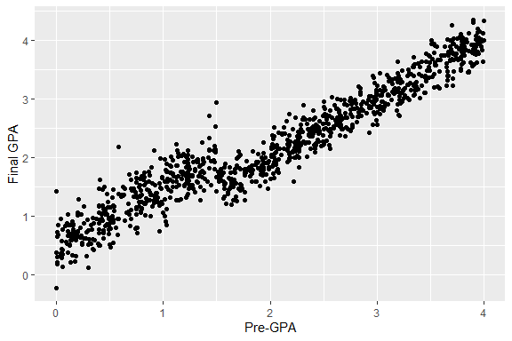

```r
ggplot(sum_sch_df, aes(x=pre_gpa, y=fgpa_obs)) +
  geom_point() + xlab("Pre-GPA") + ylab("Final GPA")
```

## Solution 2 - Take **difference** in GPA

```r
sum_sch_df <- sum_sch_df %>%
  mutate(gpa_diff = fgpa_obs - pre_gpa)
sumsch_lm3 <- lm(gpa_diff ~ sumschl, data = sum_sch_df)
summary(sumsch_lm3)
```

```
##
## Call:
## lm(formula = gpa_diff ~ sumschl, data = sum_sch_df)
##
## Residuals:
##      Min       1Q   Median       3Q      Max
## -0.73838 -0.15065 -0.00065  0.14935  1.09162
##
## Coefficients:
##              Estimate Std. Error t value Pr(>|t|)
## (Intercept) 0.0006508  0.0094151   0.069    0.945
## sumschlTRUE 0.5177276  0.0154783  33.449   <2e-16 ***
## ---
## Signif. codes:  0 '***' 0.001 '**' 0.01 '*' 0.05 '.' 0.1 ' ' 1
##
## Residual standard error: 0.2363 on 998 degrees of freedom
## Multiple R-squared:  0.5285, Adjusted R-squared:  0.5281
## F-statistic:  1119 on 1 and 998 DF,  p-value: < 2.2e-16
```

## Solution 3 - Only keep observations around the cutoff

```r
sum_sch_rd <- sum_sch_df %>%
  filter(pre_gpa>1.4 & pre_gpa <1.6)

sumsch_lm4 <- lm(fgpa_obs ~ sumschl, data = sum_sch_rd)
summary(sumsch_lm4)
```

```
##
## Call:
## lm(formula = fgpa_obs ~ sumschl, data = sum_sch_rd)
##
## Residuals:
##      Min       1Q   Median       3Q      Max
## -0.56789 -0.15342  0.01000  0.09158  0.83211
##
## Coefficients:
##             Estimate Std. Error t value Pr(>|t|)
## (Intercept)  1.61000    0.05490  29.324  < 2e-16 ***
## sumschlTRUE  0.49789    0.08163   6.099 3.43e-07 ***
## ---
## Signif. codes:  0 '***' 0.001 '**' 0.01 '*' 0.05 '.' 0.1 ' ' 1
##
## Residual standard error: 0.2633 on 40 degrees of freedom
## Multiple R-squared:  0.4819, Adjusted R-squared:  0.4689
## F-statistic:  37.2 on 1 and 40 DF,  p-value: 3.426e-07
```

## Let’s back up

- The point here is that **modeling** should not be our first step
- We need to think about what the correct model is for the parameter we want to estimate
- Failing to do so will lead us confuse correlation and causation

## A few new ideas/concepts

- **Counterfactual** - Imagine an alternate dimension **exactly** like this one, where the only difference is that you were enrolled in summer school
- **Treatment Assignment Mechanism** - Before estimating anything, we need to understand why some people are getting treated and others aren’t
  - The more random treatment is the better
- **No One Causal Effect** - There will never be only one. Our job is to pick (and estimate) the most useful one.

## Brief tangent about counterfactuals

- Counterfactuals are, of course, unknowable
- For the longest time, this **freaked** statisticians out
- Often overly cautious with causal language
- I will spare you a rant, but see **The Book of Why** by Judea Pearl
- This was overcome with introduction of **notation** and **treatment assignment**

## Potential Outcomes Notation - Treatment

Back to our example, let treatment be binary:

$$D_{i,t} =\begin{cases} 1 \text{ if sent
to summer school at time $t$} \\ 0 \text{ if not sent to summer school
at time $t$} \end{cases}$$

where $i$ indexes an individual observation, such as a person

## Potential Outcomes Notation - Outcomes

Each individual has two potential outcomes, based on whether they receive treatment

$$Y_{i,t}^j =\begin{cases} 1 \text{ GPA if
attends summer school at time $t$} \\ 0 \text{ GPA if does not attend
summer school at time $t$} \end{cases}$$

where $j$ indexes a potential treatment status for the same $i$ person at the same $t$ point in time. Let Sue have GPA of 2.1 with summer school and 1.8 without in period 2. Then:

$$Y_{Sue,2}^1 = 2.1$$
$$Y_{Sue,2}^0 = 1.8$$

## Potential Outcomes - Cont’d

- Potential outcome $Y^j$ refers to the “a priori fixed but unknown” outcomes associated with different possible treatment assignments
- Realized outcome $Y$ refers to the “posterior and known” outcome associated with a specific treatment assignment
- Potential outcomes become realized outcomes through treatment assignment
  - This assignment *might* be random
  - Our job to understand it

## Treatment Assignment and Modeling

- The **Treatment Assignment Mechanism** drives our efforts to estimate a causal effect
  - Can make things easy (randomized)
  - Or nearly impossible (endogenous in unmeasurable ways)
- Put differently, the same model can be *biased* or *unbiased* depending on treatment assignment
- This means we need to pick our model *after* we understand treatment assignment

## Important Definitions (1/7)

- **Definition 1: Individual treatment effect**
  - The individual treatment effect, $\delta_i$, associated with summer school attendance is equal to $Y_i^1-Y_i^0$.

## Important Definitions (2/7)

- **Definition 2: Switching equation**
  - An individual’s realized health outcome, $Y_i$, is determined by treatment assignment, $D_i$ which selects one of the potential outcomes:
    $$\begin{eqnarray*}
    Y_i& = D_iY^1_i+(1-D_i)Y^0_i& \\
    Y_i& = \begin{cases}
    Y^1_i\text{ if }D_i=1 \\
    Y^0_i\text{ if }D_i=0
    \end{cases}
    \end{eqnarray*}$$

## Important Definitions (3/7)

- **Definition 3: Fundamental problem of causal inference**
  - If you need both potential outcomes to know causality with certainty, then since it is impossible to observe both $Y_i^1$ and $Y_i^0$ for the same individual, $\delta_i$, is *unknowable*.
  - However, we can *estimate* it.
- This is why statisticians generally avoid causal language

## Causal Inference is a Missing Data Problem

- Fundamental problem of causal inference is deep and impossible to perfectly overcome
  - not even with more data
- Causal inference is a missing data problem
- All of causal inference involves imputing missing counterfactuals and not all imputations are equal

## Important Definitions (4/7)

- **Definition 4: Average Treatment Effect (ATE)**
  - The average treatment effect is the population average of all $i$ individual treatment effects
    $$\begin{eqnarray*}
    E[\delta_i]&=&E[Y_i^1-Y_i^0]\\
    &=&E[Y^1_i] - E[Y^0_i]
    \end{eqnarray*}$$
- Aggregate parameters based on individual treatment effects are *summaries* of individual treatment effects

## Important Definitions (5/7)

- **Definition 5: Average Treatment Effect on the Treated (ATT)**
  - The average treatment effect on the treatment group is equal to the average treatment effect conditional on being a treatment group member:
    $$\begin{eqnarray*}
    E[\delta|D=1]&=&E[Y^1-Y^0|D=1] \nonumber \\
    &=&E[Y^1|D=1]-E[Y^0|D=1]
    \end{eqnarray*}$$

## Important Definitions (6/7)

- **Definition 6: Average Treatment Effect on the Untreated (ATU)**
  - The average treatment effect on the untreated group is equal to the average treatment effect conditional on being untreated:
    $$\begin{eqnarray*}
    E[\delta|D=0]&=&E[Y^1-Y^0|D=0] \nonumber \\
    &=&E[Y^1|D=0]-E[Y^0|D=0]
    \end{eqnarray*}$$
  - We will never observe this with observational data

## Average Treatment Effects are Simple Summaries

- Notice how in all three of these, all we did was take the defined treatment effect at the individual and aggregate
- Because aggregate causal parameters are *summaries* of individual treatment effects, each of which cannot be calculated, the aggregates cannot be calculated either
- While we cannot measure average causal effects, we can **estimate** them, but only in special situations

## Let’s check for understanding

```r
head(ss_df)
```

```
##   pre_gpa post_no_ss post_ss
## 1     1.8        1.9     2.2
## 2     2.1        2.3     2.5
## 3     2.4        2.2     2.2
## 4     1.5        1.5     2.0
```

- Calculate the ATE, ATT, and ATU, when the treatment assignment occurs at GPA of 2 or less

## First, need individual treatment effects

```r
ss_df <- ss_df %>%
  mutate(treat = pre_gpa < 2,
         ind_te = post_ss - post_no_ss)
head(ss_df)
```

```
##   pre_gpa post_no_ss post_ss treat ind_te
## 1     1.8        1.9     2.2  TRUE    0.3
## 2     2.1        2.3     2.5 FALSE    0.2
## 3     2.4        2.2     2.2 FALSE    0.0
## 4     1.5        1.5     2.0  TRUE    0.5
```

- Notice, we didn’t even need to calculate the actual realized outcomes

## ATE

- ATE is the average of all the individual treatment effects, regardless of whether they got treated
- $ATE = \frac{.3 + .2 + 0 + .5}{4} = \frac{1}{4} = .25$
- or by code:

```r
mean(ss_df$ind_te)
```

```
## [1] 0.25
```

## ATT

- ATT is the average of all the individual treatment effects, *only for those who ended up receiving treatment*
- $ATT = \frac{.3 + .5}{2} = \frac{.8}{2} = .4$
- or by code:

```r
mean(ss_df$ind_te[ss_df$treat==TRUE])
```

```
## [1] 0.4
```

## ATU

- ATU is the average of all the individual treatment effects, *only for those who ended up NOT receiving treatment*
- $ATU = \frac{.2 + .0}{2} = \frac{.2}{2} = .1$
- or by code:

```r
mean(ss_df$ind_te[ss_df$treat==FALSE])
```

```
## [1] 0.1
```

- What does this tell us about treatment targeting?

## Important Definitions (7/7)

- **Definition 7: Simple Difference in Outcomes (SDO)**
  - A simple difference in mean outcomes (SDO) can be calculated as:

  $$\begin{eqnarray*}
  SDO &=& E[Y^1 | D=1] - E[Y^0 | D=0]
  \end{eqnarray*}$$
- SDO is **not a causal parameter** because it’s comparing $Y^1$ and $Y^0$ for different units, not the same units
  - So what is it measuring?

## SDO is made up of three things

$$\begin{eqnarray*}
\underbrace{\hat{SDO}}_{{\text{Estimate of SDO}}}&=&
\underbrace{E[Y^1] - E[Y^0]}_{{\text{Average Treatment Effect}}} \\
&& + \underbrace{{E[Y^0|D=1]} - E[Y^0 |
D=0]}_{{\text{Selection bias}}} \\
&& + \underbrace{(1-\pi)(ATT - ATU)}_{{\text{Heterogenous
treatment effect bias}}}
\end{eqnarray*}$$

- where $\pi$ is the share of units in the treatment group
- why does randomization clean this up?

## Let’s try to make sense of this

- Remember the data we created at the beginning of the lecture?

```r
head(sum_sch_df)
```

```
##   pre_gpa sumschl ss_effect noise fgpa_nss fgpa_ss fgpa_obs gpa_diff
## 1    0.45    TRUE      0.70  0.36     0.81    1.51     1.51     1.06
## 2    2.49   FALSE      0.26 -0.27     2.22    2.47     2.22    -0.27
## 3    2.44   FALSE      0.64 -0.14     2.30    2.94     2.30    -0.14
## 4    2.49   FALSE      0.48 -0.11     2.38    2.86     2.38    -0.11
## 5    3.44   FALSE      0.86 -0.06     3.38    4.24     3.38    -0.06
## 6    2.56   FALSE      0.45 -0.08     2.49    2.94     2.49    -0.07
```

## Breaking down the SDO

```r
mean_treated <- mean(sum_sch_df$fgpa_obs[sum_sch_df$sumschl==TRUE])
mean_untreated <- mean(sum_sch_df$fgpa_obs[sum_sch_df$sumschl==FALSE])
SDO <- mean_treated - mean_untreated
SDO
```

```
## [1] -1.501698
```

## ATE, ATT, ATU (Should be the same, why?)

```r
ATE <- mean(sum_sch_df$ss_effect)
ATT <- mean(sum_sch_df$ss_effect[sum_sch_df$sumschl==TRUE])
ATU <- mean(sum_sch_df$ss_effect[sum_sch_df$sumschl==FALSE])
ATE
```

```
## [1] 0.49766
```

```r
ATT
```

```
## [1] 0.5067838
```

```r
ATU
```

```
## [1] 0.4923016
```

## pi, the proportion of students who are treated

```r
pi <- mean(sum_sch_df$sumschl)
pi
```

```
## [1] 0.37
```

## Selection Bias

$\underbrace{{E[Y^0|D=1]} - E[Y^0 | D=0]}_{{\text{Selection bias}}}$

- This is the difference in *untreated* outcomes across groups

```r
y0_d1 <- mean(sum_sch_df$fgpa_nss[sum_sch_df$sumschl==TRUE])
y0_d0 <- mean(sum_sch_df$fgpa_nss[sum_sch_df$sumschl==FALSE])
selection_bias <- y0_d1 - y0_d0
selection_bias
```

```
## [1] -2.008482
```

## Putting it all together

$\underbrace{SDO}_{-1.5017} = \underbrace{ATE}_{.49766} + \underbrace{SelectionBias}_{-2.008} + \underbrace{(1-\pi)}_{.63}(\underbrace{ATT}_{.5068}-\underbrace{ATU}_{.4923})$

## What about with heterogeneous treatment effects?

```r
pre_gpa <- runif(1000,max=4,min=0)
sumschl <- pre_gpa <1.5
ss_effect <- rnorm(1000,.5,.2)*((4-pre_gpa)/4)
noise <- rnorm(1000,0,.2)
fgpa_nss <- pre_gpa + noise
fgpa_ss <- pre_gpa + noise + ss_effect
fgpa_obs <- pre_gpa + noise + sumschl*ss_effect
sum_sch_df <- data.frame(pre_gpa, sumschl, ss_effect, noise, fgpa_nss,fgpa_ss,fgpa_obs)
```

## Calculate the new SDO

```r
mean_treated <- mean(sum_sch_df$fgpa_obs[sum_sch_df$sumschl==TRUE])
mean_untreated <- mean(sum_sch_df$fgpa_obs[sum_sch_df$sumschl==FALSE])
SDO <- mean_treated - mean_untreated
SDO
```

```
## [1] -1.604537
```

## Recaculate Selection Bias

$\underbrace{{E[Y^0|D=1]} - E[Y^0 | D=0]}_{{\text{Selection bias}}}$

- This is the difference in *untreated* outcomes across the groups

```r
y0_d1 <- mean(sum_sch_df$fgpa_nss[sum_sch_df$sumschl==TRUE])
y0_d0 <- mean(sum_sch_df$fgpa_nss[sum_sch_df$sumschl==FALSE])
selection_bias <- y0_d1 - y0_d0
selection_bias
```

```
## [1] -2.000438
```

## New ATE, ATT, ATU (Now they are different)

```r
ATE <- mean(sum_sch_df$ss_effect)
ATT <- mean(sum_sch_df$ss_effect[sum_sch_df$sumschl==TRUE])
ATU <- mean(sum_sch_df$ss_effect[sum_sch_df$sumschl==FALSE])
ATE
```

```
## [1] 0.24834
```

```r
ATT
```

```
## [1] 0.395953
```

```r
ATU
```

```
## [1] 0.1567099
```

## pi, the proportion of students who are treated

```r
pi <- mean(sum_sch_df$sumschl)
pi
```

```
## [1] 0.383
```

## Putting it all together

$\underbrace{SDO}_{-1.605} = \underbrace{ATE}_{.248} + \underbrace{SelectionBias}_{-2.000} + \underbrace{(1-\pi)}_{.617}(\underbrace{ATT}_{.396}-\underbrace{ATU}_{.157})$

## Which Treatment Effect can we estimate in this setting?

```r
sumsch_lm4 <- lm(fgpa_obs ~ sumschl + pre_gpa, data = sum_sch_df)
summary(sumsch_lm4)
```

```
##
## Call:
## lm(formula = fgpa_obs ~ sumschl + pre_gpa, data = sum_sch_df)
##
## Residuals:
##      Min       1Q   Median       3Q      Max
## -0.72366 -0.14874 -0.00764  0.15705  0.65694
##
## Coefficients:
##             Estimate Std. Error t value Pr(>|t|)
## (Intercept)  0.03210    0.03325   0.965    0.335
## sumschlTRUE  0.35335    0.02722  12.982   <2e-16 ***
## pre_gpa      0.98810    0.01163  84.929   <2e-16 ***
## ---
## Signif. codes:  0 '***' 0.001 '**' 0.01 '*' 0.05 '.' 0.1 ' ' 1
##
## Residual standard error: 0.2224 on 997 degrees of freedom
## Multiple R-squared:  0.9514, Adjusted R-squared:  0.9513
## F-statistic:  9755 on 2 and 997 DF,  p-value: < 2.2e-16
```

## Note that randomization turns the ATT into the ATE

- With randomization, $ATT = ATU$
- $ATE$ is just a weighted average of $ATT$ AND $ATU$
- Now, $ATE=ATT=ATU$

## In class assignment

Use this setup:

```r
set.seed(12345)
pre_health <- runif(10000,max=10,min=0)
intervention <- pre_health < 3
het_treat_effect <- (10-pre_health)/10
effect <- rnorm(10000,2,1)*het_treat_effect
```

- Find the ATE, ATT, and ATU

## ATE

```r
ATE <- mean(effect)
ATE
```

```
## [1] 0.9962289
```

## ATT

```r
ATT <- mean(effect[intervention==1])
ATT
```

```
## [1] 1.684293
```

## ATU

```r
ATU <- mean(effect[intervention==0])
ATU
```

```
## [1] 0.7048423
```